# Jaekaupluste müügimahtude ja laovarude kirjeldav analüüs

Seminaritöö 1 õppeaines RAM0580 Andmeanalüüs

Koostaja: Andre Toodre

Esitatud: 17.10.2026

# 1 Sissejuhatus

## 1.1 Andmestiku kirjeldus

Andmestik **Retail Store Inventory Forecasting Dataset** pärineb portaalist [Kaggle](https://www.kaggle.com/datasets/anirudhchauhan/retail-store-inventory-forecasting-dataset) (autor Anirudh Chauhan). Andmestik sisaldab jaekaupluste igapäevaseid müügi- ja laoandmeid ajavahemikus 01.01.2022 – 01.01.2024. Iga rida on ühe toote andmed ühes kaupluses ühel päeval. Andmestik on **sünteetiline**, st andmed on genereeritud müügi prognoosimise harjutamiseks ega pärine päris kauplustest.

Tunnuste kirjeldus:

| Tunnus | Kirjeldus | Tüüp |
| --- | --- | --- |
| Date | Kuupäev | kuupäev |
| Store ID | Kaupluse tunnus (S001–S005) | kategoriaalne |
| Product ID | Toote tunnus (P0001–P0020) | kategoriaalne |
| Category | Tootekategooria (Clothing, Electronics, Furniture, Groceries, Toys) | kategoriaalne |
| Region | Piirkond (East, North, South, West) | kategoriaalne |
| Inventory Level | Laoseis päeva alguses (tk) | arvuline |
| Units Sold | Päeva jooksul müüdud kogus (tk) | arvuline |
| Units Ordered | Tellitud kogus (tk) | arvuline |
| Demand Forecast | Prognoositud nõudlus (tk) | arvuline |
| Price | Toote hind | arvuline |
| Discount | Allahindlus (%) | arvuline |
| Weather Condition | Ilm (Cloudy, Rainy, Snowy, Sunny) | kategoriaalne |
| Holiday/Promotion | Kas päev oli püha või kampaaniapäev (0 = ei, 1 = jah) | kategoriaalne |
| Competitor Pricing | Konkurendi hind samale tootele | arvuline |
| Seasonality | Aastaaeg (Autumn, Spring, Summer, Winter) | kategoriaalne |

## 1.2 Uurimiseesmärk

Töö eesmärk on uurida, millest sõltub **toote päevane müügimaht** (`Units.Sold`). Kas müük on seotud laoseisu, hinna, allahindluse, tootekategooria, piirkonna, ilma, kampaaniate või aastaajaga? Tulevikus saaks nende tegurite põhjal müüki prognoosida ja laovarusid planeerida.

Seminaritöö 1 eesmärk on andmete kirjeldav analüüs.

# 2 Andmete lugemine ja ülevaade andmetest

Loeme andmed R-i sisse:

```r
retail <- read.csv("retail_store_inventory.csv")
```

Andmetabel (esimesed 1000 rida, sest täistabel teeks HTML-faili liiga suureks):

```r
library(DT)
datatable(head(retail, 1000), options = list(scrollX = 1, pageLength = 5, searching = TRUE, scroller = TRUE, scrollY = 200))
```

|  | Date | Store.ID | Product.ID | Category | Region | Inventory.Level | Units.Sold | Units.Ordered | Demand.Forecast | Price | Discount | Weather.Condition | Holiday.Promotion | Competitor.Pricing | Seasonality |
| --- | --- | --- | --- | --- | --- | --- | --- | --- | --- | --- | --- | --- | --- | --- | --- |
| 1 | 2022-01-01 | S001 | P0001 | Groceries | North | 231 | 127 | 55 | 135.47 | 33.5 | 20 | Rainy | 0 | 29.69 | Autumn |
| 2 | 2022-01-01 | S001 | P0002 | Toys | South | 204 | 150 | 66 | 144.04 | 63.01 | 20 | Sunny | 0 | 66.16 | Autumn |
| 3 | 2022-01-01 | S001 | P0003 | Toys | West | 102 | 65 | 51 | 74.02 | 27.99 | 10 | Sunny | 1 | 31.32 | Summer |
| 4 | 2022-01-01 | S001 | P0004 | Toys | North | 469 | 61 | 164 | 62.18 | 32.72 | 10 | Cloudy | 1 | 34.74 | Autumn |
| 5 | 2022-01-01 | S001 | P0005 | Electronics | East | 166 | 14 | 135 | 9.26 | 73.64 | 0 | Sunny | 0 | 68.95 | Summer |
| 6 | 2022-01-01 | S001 | P0006 | Groceries | South | 138 | 128 | 102 | 139.82 | 76.83 | 10 | Sunny | 1 | 79.35 | Winter |
| 7 | 2022-01-01 | S001 | P0007 | Furniture | East | 359 | 97 | 167 | 108.92 | 34.16 | 10 | Rainy | 1 | 36.55 | Winter |
| 8 | 2022-01-01 | S001 | P0008 | Clothing | North | 380 | 312 | 54 | 329.73 | 97.99 | 5 | Cloudy | 0 | 100.09 | Spring |
| 9 | 2022-01-01 | S001 | P0009 | Electronics | West | 183 | 175 | 135 | 174.15 | 20.74 | 10 | Cloudy | 0 | 17.66 | Autumn |
| 10 | 2022-01-01 | S001 | P0010 | Toys | South | 108 | 28 | 196 | 24.47 | 59.99 | 0 | Rainy | 1 | 61.21 | Winter |

[output cut: 990 more lines]

Ülevaade andmestiku struktuurist:

```r
str(retail)
```

```
## 'data.frame':    73100 obs. of  15 variables:
##  $ Date              : chr  "2022-01-01" "2022-01-01" "2022-01-01" "2022-01-01" ...
##  $ Store.ID          : chr  "S001" "S001" "S001" "S001" ...
##  $ Product.ID        : chr  "P0001" "P0002" "P0003" "P0004" ...
##  $ Category          : chr  "Groceries" "Toys" "Toys" "Toys" ...
##  $ Region            : chr  "North" "South" "West" "North" ...
##  $ Inventory.Level   : int  231 204 102 469 166 138 359 380 183 108 ...
##  $ Units.Sold        : int  127 150 65 61 14 128 97 312 175 28 ...
##  $ Units.Ordered     : int  55 66 51 164 135 102 167 54 135 196 ...
##  $ Demand.Forecast   : num  135.47 144.04 74.02 62.18 9.26 ...
##  $ Price             : num  33.5 63 28 32.7 73.6 ...
##  $ Discount          : int  20 20 10 10 0 10 10 5 10 0 ...
##  $ Weather.Condition : chr  "Rainy" "Sunny" "Sunny" "Cloudy" ...
##  $ Holiday.Promotion : int  0 0 1 1 0 1 1 0 0 1 ...
##  $ Competitor.Pricing: num  29.7 66.2 31.3 34.7 69 ...
##  $ Seasonality       : chr  "Autumn" "Autumn" "Summer" "Autumn" ...
```

Arvuliste ja mittearvuliste tunnuste arv:

```r
n_numeric <- sum(sapply(retail, is.numeric))
n_non_numeric <- ncol(retail) - n_numeric
c(objects = nrow(retail), variables = ncol(retail), numeric = n_numeric, non_numeric = n_non_numeric)
```

```
##     objects   variables     numeric non_numeric
##       73100          15           8           7
```

Andmestikus on **73100 objekti** ja **15 tunnust**. R loeb neist **8 tunnust arvuliseks** (*int* ja *num*) ja **7 mittearvuliseks** (*chr*). R muudab lugemisel tunnuste nimedes tühikud ja kaldkriipsud punktideks (nt `Store ID` → `Store.ID`).

R-i määratud tüübid ei vasta alati tunnuste sisule:

- `Date` on tekst (*chr*), aga see on kuupäev. Sellest saab tuletada kuu ja aastaaja.
- `Holiday.Promotion` on tüübilt arvuline (*int*), aga sisult kahe väärtusega (0/1) **kategoriaalne** tunnus.
- `Discount` on arvuline, aga sellel on ainult 5 väärtust (0, 5, 10, 15, 20 %). Jätame selle arvuliseks, sest väärtused on järjestatud ja nende vahed on võrdsed.

## 2.1 Projekti eesmärk ja tunnuste valik

**Sihttunnus** on `Units.Sold`, toote päevane müügimaht tükkides. See on arvuline tunnus vahemikus 0–499. Kuna erinevaid väärtusi on palju (498), käsitleme seda pideva tunnusena.

Eeldame, et müük sõltub järgmistest teguritest:

- laoseis (`Inventory.Level`): müüa saab ainult seda, mis on laos;
- hind, allahindlus ja konkurendi hind (`Price`, `Discount`, `Competitor.Pricing`);
- tootekategooria, kauplus ja piirkond (`Category`, `Store.ID`, `Region`);
- välised tegurid: ilm, pühad/kampaaniad, aastaaeg (`Weather.Condition`, `Holiday.Promotion`, `Seasonality`).

`Units.Ordered` (tellitud kogus) on tellimuse otsus, mitte müügi põhjus. Jätame selle kirjeldavasse analüüsi, et näha, kas tellimused on müügiga seotud. Tunnus `Product.ID` jääb samuti alles: 20 toodet ei ole liiga palju kategooriaid.

`Demand.Forecast` (nõudluse prognoos) vajab eraldi kontrolli:

```r
cor(retail$Units.Sold, retail$Demand.Forecast)
```

```
## [1] 0.996853
```

```r
summary(retail$Demand.Forecast - retail$Units.Sold)
```

```
##    Min. 1st Qu.  Median    Mean 3rd Qu.    Max.
##  -10.00   -2.47    4.99    5.03   12.51   20.00
```

Prognoos erineb tegelikust müügist ainult vahemikus −10 kuni +20 ühikut (r = 0.997). Prognoos on seega arvutatud tegeliku müügi põhjal ega ole müügist sõltumatu tegur. Mudelis tähendaks selle kasutamine andmeleket: me ei tea päeva müüki enne, kui päev on läbi. Lisaks on prognoosides negatiivseid väärtusi. Käsitleme neid puhastamise osas.

### 2.1.1 Tunnuste teisendused

**Kuupäev.** Teisendame `Date` kuupäevaks ja tuletame sellest kuu (`Month`) ja aastaaja (`Season`):

```r
retail$Date <- as.Date(retail$Date)
range(retail$Date)
```

```
## [1] "2022-01-01" "2024-01-01"
```

```r
table(format(retail$Date, "%Y"))
```

```
##
##  2022  2023  2024
## 36500 36500   100
```

Aasta 2024 kohta on andmed ainult ühe päeva (01.01.2024) kohta. Seetõttu ei kasuta me aastat eraldi tunnusena.

```r
retail$Month <- format(retail$Date, "%m")
month_num <- as.integer(retail$Month)
retail$Season <- ifelse(month_num %in% c(12, 1, 2), "Winter",
                 ifelse(month_num %in% 3:5, "Spring",
                 ifelse(month_num %in% 6:8, "Summer", "Autumn")))
```

**Aastaaja kontroll.** Võrdleme kuupäevast tuletatud aastaaega andmestikus oleva tunnusega `Seasonality`:

```r
table(Season_from_date = retail$Season, Seasonality = retail$Seasonality)
```

```
##                 Seasonality
## Season_from_date Autumn Spring Summer Winter
##           Autumn   4508   4613   4566   4513
##           Spring   4592   4691   4536   4581
##           Summer   4514   4534   4674   4678
##           Winter   4579   4479   4529   4513
```

Tunnus `Seasonality` **ei vasta kuupäevale**: igal aastaajal on peaaegu võrdselt kõiki nelja `Seasonality` väärtust. Näiteks talvekuudel on „Summer” sama sageli kui „Winter”. Tunnus on genereeritud juhuslikult. Jätame `Seasonality` välja ja kasutame kuupäevast tuletatud tunnust `Season`.

**Kaupluse ja piirkonna ning toote ja kategooria kontroll.** Sarnast vastuolu on näha ka teistes tunnustes:

```r
table(retail$Store.ID, retail$Region)
```

```
##
##        East North South West
##   S001 3675  3637  3663 3645
##   S002 3749  3622  3671 3578
##   S003 3636  3669  3678 3637
##   S004 3620  3662  3621 3717
##   S005 3669  3638  3664 3649
```

```r
head(table(retail$Product.ID, retail$Category), 5)
```

```
##
##         Clothing Electronics Furniture Groceries Toys
##   P0001      744         700       720       763  728
##   P0002      718         727       753       729  728
##   P0003      717         689       735       759  755
##   P0004      711         747       725       727  745
##   P0005      697         743       740       754  721
```

Sama kauplus asub andmetes kõigis neljas piirkonnas ja sama toode kuulub kõigisse viide kategooriasse. Päris andmetes on kauplusel üks asukoht ja tootel üks kategooria. Jätame need tunnused alles, aga peame arvestama, et nende seos müügiga ei pruugi olla sisuliselt tõlgendatav.

**Loogikakontroll.** Müük ei saa ületada laoseisu:

```r
sum(retail$Units.Sold > retail$Inventory.Level)
```

```
## [1] 0
```

Selliseid objekte ei ole, seega on see tingimus täidetud.

Eemaldame analüüsiks mittevajalikud tunnused: `Seasonality` (vastuoluline) ja `Date` (kuupäevast vajalik info on nüüd tunnustes `Month` ja `Season`).

```r
retail <- retail[, !(names(retail) %in% c("Seasonality", "Date"))]
```

Ülevaade andmestikust paketi **skimr** funktsiooniga **skim()**:

```r
library(skimr)
skim(retail)
```

Data summary

| Name | retail |
| --- | --- |
| Number of rows | 73100 |
| Number of columns | 15 |
| _______________________ |  |
| Column type frequency: |  |
| character | 7 |
| numeric | 8 |
| ________________________ |  |
| Group variables | None |

**Variable type: character**

| skim_variable | n_missing | complete_rate | min | max | empty | n_unique | whitespace |
| --- | --- | --- | --- | --- | --- | --- | --- |
| Store.ID | 0 | 1 | 4 | 4 | 0 | 5 | 0 |
| Product.ID | 0 | 1 | 5 | 5 | 0 | 20 | 0 |
| Category | 0 | 1 | 4 | 11 | 0 | 5 | 0 |
| Region | 0 | 1 | 4 | 5 | 0 | 4 | 0 |
| Weather.Condition | 0 | 1 | 5 | 6 | 0 | 4 | 0 |
| Month | 0 | 1 | 2 | 2 | 0 | 12 | 0 |
| Season | 0 | 1 | 6 | 6 | 0 | 4 | 0 |

**Variable type: numeric**

| skim_variable | n_missing | complete_rate | mean | sd | p0 | p25 | p50 | p75 | p100 | hist |
| --- | --- | --- | --- | --- | --- | --- | --- | --- | --- | --- |
| Inventory.Level | 0 | 1 | 274.47 | 129.95 | 50.00 | 162.00 | 273.00 | 387.00 | 500.00 | ▇▇▇▇▇ |
| Units.Sold | 0 | 1 | 136.46 | 108.92 | 0.00 | 49.00 | 107.00 | 203.00 | 499.00 | ▇▅▂▂▁ |
| Units.Ordered | 0 | 1 | 110.00 | 52.28 | 20.00 | 65.00 | 110.00 | 155.00 | 200.00 | ▇▇▇▇▇ |
| Demand.Forecast | 0 | 1 | 141.49 | 109.25 | -9.99 | 53.67 | 113.02 | 208.05 | 518.55 | ▇▆▃▂▁ |
| Price | 0 | 1 | 55.14 | 26.02 | 10.00 | 32.65 | 55.05 | 77.86 | 100.00 | ▇▇▇▇▇ |
| Discount | 0 | 1 | 10.01 | 7.08 | 0.00 | 5.00 | 10.00 | 15.00 | 20.00 | ▇▇▇▇▇ |
| Holiday.Promotion | 0 | 1 | 0.50 | 0.50 | 0.00 | 0.00 | 0.00 | 1.00 | 1.00 | ▇▁▁▁▇ |
| Competitor.Pricing | 0 | 1 | 55.15 | 26.19 | 5.03 | 32.68 | 55.01 | 77.82 | 104.94 | ▆▇▇▇▆ |

**Jaotuste kommentaar**

- **Arvtunnused.** `Inventory.Level`, `Units.Ordered`, `Price`, `Discount` ja `Competitor.Pricing` on ligikaudu **ühtlase jaotusega**: histogrammid on peaaegu tasased, keskmine ja mediaan praktiliselt võrdsed. Jaotused on seega sümmeetrilised. See on genereeritud andmetele omane, päris müügiandmed on harva nii ühtlased. Sihttunnus `Units.Sold` ja `Demand.Forecast` on **paremale kaldu**: väikseid müügikoguseid on rohkem kui suuri, keskmine (136.5) on suurem kui mediaan (107).
- **Kategoriaalsed tunnused** on erakordselt **ühtlaselt jaotunud**: igas kategoorias on ligikaudu sama palju objekte. Näiteks on igas tootekategoorias ~14 600 rida, igas piirkonnas ~18 250 rida ja pühade/kampaaniate päevi ~50%. Kaupluste kaupa on ridu täpselt võrdselt (14 620).

# 3 Andmestiku puhastamine

## 3.1 Duplikaatide kontroll

Duplikaatide kontroll funktsiooniga **duplicated()**:

```r
sum(duplicated(retail))
```

```
## [1] 0
```

Andmestikus on 0 duplikaati. Kontrollime ka, kas sama kaupluse, toote ja päeva kombinatsioon esineb mitu korda. See oleks sisuline duplikaat isegi siis, kui ülejäänud väärtused erinevad. Kuupäev on eemaldatud, seega kontrollime seda algandmetest:

```r
raw_keys <- read.csv("retail_store_inventory.csv")[, c("Date", "Store.ID", "Product.ID")]
sum(duplicated(raw_keys))
```

```
## [1] 0
```

```r
retail <- retail[!duplicated(retail), ]
```

## 3.2 Puuduvate väärtuste kontroll

Puuduvate väärtuste olemasolu kontrollimine funktsiooni **is.na()** abil:

```r
sum(is.na(retail))
```

```
## [1] 0
```

Kontrollime ka tühje lahtreid tekstitunnustes:

```r
char_vars <- names(Filter(is.character, retail))
sapply(retail[, char_vars], function(x) sum(x == ""))
```

```
##          Store.ID        Product.ID          Category            Region
##                 0                 0                 0                 0
## Weather.Condition             Month            Season
##                 0                 0                 0
```

Andmestikus ei ole ei `NA` väärtusi ega tühje lahtreid. Sisuliselt puuduvad väärtused võivad aga olla peidetud võimatute väärtuste taha. Kontrollime arvtunnuste miinimume:

```r
sapply(Filter(is.numeric, retail), min)
```

```
##    Inventory.Level         Units.Sold      Units.Ordered    Demand.Forecast
##              50.00               0.00              20.00              -9.99
##              Price           Discount  Holiday.Promotion Competitor.Pricing
##              10.00               0.00               0.00               5.03
```

Negatiivne on ainult `Demand.Forecast` (min -9.99). Negatiivne nõudluse prognoos on võimatu, seega on need väärtused **vigased**. Loeme need kokku:

```r
sum(retail$Demand.Forecast < 0)
```

```
## [1] 673
```

Asendame vigased väärtused standardse sümboliga `NA`:

```r
retail$Demand.Forecast[retail$Demand.Forecast < 0] <- NA
```

Puuduvate väärtuste arv pärast asendust:

```r
sum(is.na(retail))
```

```
## [1] 673
```

Andmestikus on nüüd 673 puuduvat väärtust.

Puuduvate väärtustega objektide arvu leiame funktsiooniga **complete.cases()**:

```r
sum(!complete.cases(retail))
```

```
## [1] 673
```

Puuduvate väärtustega objekte on 673 (0.92% andmestikust).

Uurime, mitu puuduvat väärtust on andmestiku igas veerus:

```r
na_by_var <- apply(is.na(retail), 2, sum)
na_by_var
```

```
##           Store.ID         Product.ID           Category             Region
##                  0                  0                  0                  0
##    Inventory.Level         Units.Sold      Units.Ordered    Demand.Forecast
##                  0                  0                  0                673
##              Price           Discount  Weather.Condition  Holiday.Promotion
##                  0                  0                  0                  0
## Competitor.Pricing              Month             Season
##                  0                  0                  0
```

Puuduvad väärtused on ainult tunnuses `Demand.Forecast`. Vaatame, milliste objektidega on tegu:

```r
summary(retail$Units.Sold[is.na(retail$Demand.Forecast)])
```

```
##    Min. 1st Qu.  Median    Mean 3rd Qu.    Max.
##   0.000   1.000   2.000   2.912   5.000   9.000
```

Puuduva prognoosiga on ainult väga väikese müügiga päevad (müük 0–9 tk). Kui need objektid eemaldada, kaoks sihttunnuse jaotusest peaaegu kogu madalaim osa ja jaotus nihkuks. Seepärast jätame välja **tunnuse** `Demand.Forecast`, mitte objektid. See tunnus ei sobi ka sisuliselt müügi selgitamiseks, sest see on arvutatud tegeliku müügi põhjal (vt eespool).

```r
retail <- retail[, names(retail) != "Demand.Forecast"]
```

Mittearvulistes tunnustes puuduvaid väärtusi ei olnud, seega asendust väärtusega `"Unknown"` ei ole vaja teha. Kood jääb siiski alles juhuks, kui andmed muutuvad:

```r
retail[, char_vars][is.na(retail[, char_vars])] <- "Unknown"
```

Pärast väljajätmist puuduvate väärtustega objektide arv:

```r
sum(!complete.cases(retail))
```

```
## [1] 0
```

Puuduvate väärtustega objekte enam ei ole. Eemaldamise kood jääb igaks juhuks alles:

```r
retail <- na.omit(retail)
```

# 4 Faktortunnuste moodustamine

Teisendame *chr*-tüüpi tunnused faktoriteks:

```r
retail <- as.data.frame(unclass(retail), stringsAsFactors = TRUE)
```

`Holiday.Promotion` on kodeeritud arvudega 0/1. Teisendame selle samuti faktoriks ja anname kategooriatele selged nimed. Aastaaegadele seame loogilise järjekorra:

```r
retail$Holiday.Promotion <- factor(retail$Holiday.Promotion, levels = c(0, 1), labels = c("No", "Yes"))
retail$Season <- factor(retail$Season, levels = c("Winter", "Spring", "Summer", "Autumn"))
```

Ülevaade puhastatud andmestikust:

```r
skim(retail)
```

Data summary

| Name | retail |
| --- | --- |
| Number of rows | 73100 |
| Number of columns | 14 |
| _______________________ |  |
| Column type frequency: |  |
| factor | 8 |
| numeric | 6 |
| ________________________ |  |
| Group variables | None |

**Variable type: factor**

| skim_variable | n_missing | complete_rate | ordered | n_unique | top_counts |
| --- | --- | --- | --- | --- | --- |
| Store.ID | 0 | 1 | FALSE | 5 | S00: 14620, S00: 14620, S00: 14620, S00: 14620 |
| Product.ID | 0 | 1 | FALSE | 20 | P00: 3655, P00: 3655, P00: 3655, P00: 3655 |
| Category | 0 | 1 | FALSE | 5 | Fur: 14699, Toy: 14643, Clo: 14626, Gro: 14611 |
| Region | 0 | 1 | FALSE | 4 | Eas: 18349, Sou: 18297, Nor: 18228, Wes: 18226 |
| Weather.Condition | 0 | 1 | FALSE | 4 | Sun: 18290, Rai: 18278, Sno: 18272, Clo: 18260 |
| Holiday.Promotion | 0 | 1 | FALSE | 2 | No: 36747, Yes: 36353 |
| Month | 0 | 1 | FALSE | 12 | 01: 6300, 03: 6200, 05: 6200, 07: 6200 |
| Season | 0 | 1 | FALSE | 4 | Spr: 18400, Sum: 18400, Aut: 18200, Win: 18100 |

**Variable type: numeric**

| skim_variable | n_missing | complete_rate | mean | sd | p0 | p25 | p50 | p75 | p100 | hist |
| --- | --- | --- | --- | --- | --- | --- | --- | --- | --- | --- |
| Inventory.Level | 0 | 1 | 274.47 | 129.95 | 50.00 | 162.00 | 273.00 | 387.00 | 500.00 | ▇▇▇▇▇ |
| Units.Sold | 0 | 1 | 136.46 | 108.92 | 0.00 | 49.00 | 107.00 | 203.00 | 499.00 | ▇▅▂▂▁ |
| Units.Ordered | 0 | 1 | 110.00 | 52.28 | 20.00 | 65.00 | 110.00 | 155.00 | 200.00 | ▇▇▇▇▇ |
| Price | 0 | 1 | 55.14 | 26.02 | 10.00 | 32.65 | 55.05 | 77.86 | 100.00 | ▇▇▇▇▇ |
| Discount | 0 | 1 | 10.01 | 7.08 | 0.00 | 5.00 | 10.00 | 15.00 | 20.00 | ▇▇▇▇▇ |
| Competitor.Pricing | 0 | 1 | 55.15 | 26.19 | 5.03 | 32.68 | 55.01 | 77.82 | 104.94 | ▆▇▇▇▆ |

```r
n_numeric <- sum(sapply(retail, is.numeric))
c(objects = nrow(retail), variables = ncol(retail), numeric = n_numeric, non_numeric = ncol(retail) - n_numeric)
```

```
##     objects   variables     numeric non_numeric
##       73100          14           6           8
```

Puhastatud andmestikus on **73100 objekti** ja **14 tunnust**: **6 arvulist** (Inventory.Level, Units.Sold, Units.Ordered, Price, Discount, Competitor.Pricing) ja **8 mittearvulist** (Store.ID, Product.ID, Category, Region, Weather.Condition, Holiday.Promotion, Month, Season).

# 5 Andmete kirjeldav analüüs

## 5.1 Seoste kirjeldav analüüs

### 5.1.1 Seosed arvuliste tunnuste vahel

Andmestikus on üle 70 000 objekti. Kõigi punktide korral muutuksid diagrammid ühtlaseks laiguks, seetõttu joonistame hajuvusdiagrammid juhuvalimi põhjal (5000 objekti):

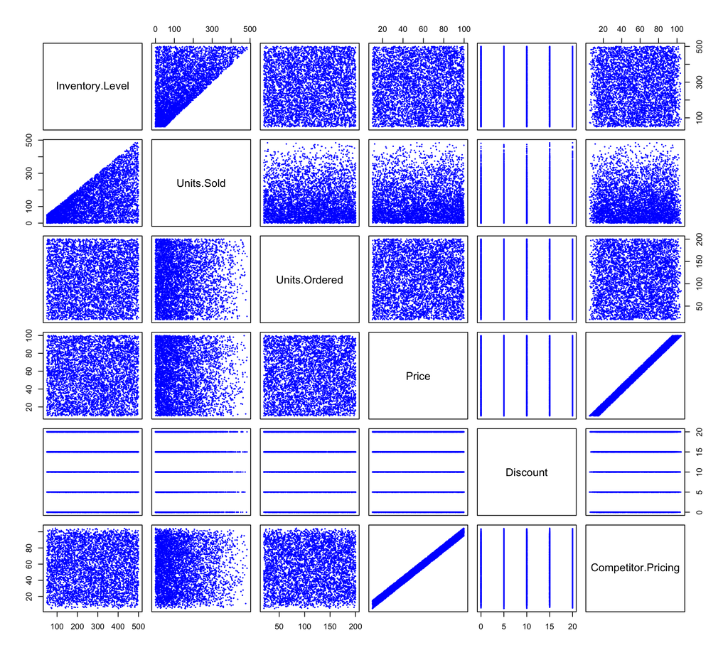

```r
set.seed(2026)
plot_sample <- retail[sample(nrow(retail), 5000), ]
plot(Filter(is.numeric, plot_sample), col = "blue", pch = 20, cex = 0.3)
```

Korrelatsioonikordajad kogu andmestiku põhjal:

```r
round(cor(Filter(is.numeric, retail)), 3)
```

```
##                    Inventory.Level Units.Sold Units.Ordered Price Discount
## Inventory.Level              1.000      0.590         0.001 0.009    0.005
## Units.Sold                   0.590      1.000        -0.001 0.001    0.003
## Units.Ordered                0.001     -0.001         1.000 0.004   -0.001
## Price                        0.009      0.001         0.004 1.000    0.002
## Discount                     0.005      0.003        -0.001 0.002    1.000
## Competitor.Pricing           0.009      0.001         0.005 0.994    0.002
##                    Competitor.Pricing
## Inventory.Level                 0.009
## Units.Sold                      0.001
## Units.Ordered                   0.005
## Price                           0.994
## Discount                        0.002
## Competitor.Pricing              1.000
```

Sihttunnusega `Units.Sold` on seotud ainult **laoseis** `Inventory.Level` (r = 0.59). Seos on positiivne: **mida suurem on laoseis, seda rohkem müüakse**. Hajuvusdiagrammil on näha seose eripärane kuju. Punktid täidavad kolmnurga, mille ülemine serv on joon `Units.Sold = Inventory.Level`. Müük ei saa laoseisu ületada, aga võib olla ükskõik milline väärtus nullist laoseisuni. Seega on laoseis müügi ülempiir, mitte täpne ennustaja.

Teiste arvtunnustega (`Units.Ordered`, `Price`, `Discount`, `Competitor.Pricing`) sihttunnus seotud ei ole: korrelatsioonid on nullilähedased ja hajuvusdiagrammid on struktuurita pilved. Eriti üllatav on, et **hind ja allahindlus ei mõjuta müüki**. Päris andmetes peaks madalam hind või suurem allahindlus müüki suurendama. Arvtunnuste vahel on veel üks tugev seos: `Price` ja `Competitor.Pricing` (r = 0.994). Konkurendi hind on peaaegu sama mis meie hind, seega on need kaks tunnust sisuliselt topelt.

### 5.1.2 Sihttunnuse seos mittearvuliste tunnustega

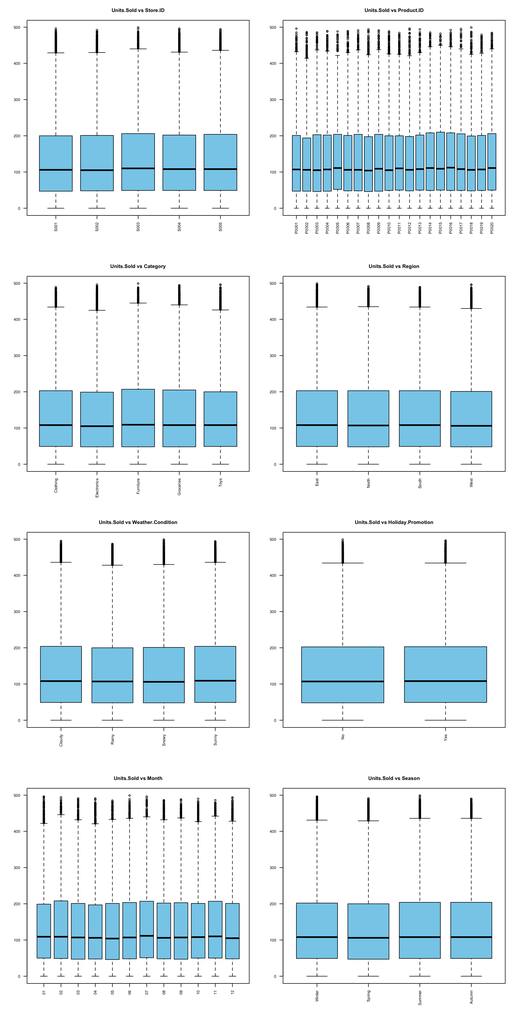

```r
factor_vars <- names(Filter(is.factor, retail))
par(mfrow = c(ceiling(length(factor_vars) / 2), 2), mar = c(6, 4, 3, 1))
for (i in 1:length(factor_vars)) {
  boxplot(retail$Units.Sold ~ retail[, factor_vars[i]], xlab = "", ylab = "",
          col = "skyblue", main = paste("Units.Sold vs", factor_vars[i]),
          cex.axis = 0.7, cex.main = 0.9, las = 2)
}
```

Müügi keskmine iga mittearvulise tunnuse kategooriates:

```r
for (v in factor_vars) {
  cat("\n", v, "\n")
  print(round(tapply(retail$Units.Sold, retail[, v], mean), 1))
}
```

```
##
##  Store.ID
##  S001  S002  S003  S004  S005
## 135.1 136.0 138.4 135.4 137.5
##
##  Product.ID
## P0001 P0002 P0003 P0004 P0005 P0006 P0007 P0008 P0009 P0010 P0011 P0012 P0013
## 136.3 133.5 135.0 135.6 137.8 136.0 136.6 133.7 137.4 135.8 136.6 134.5 137.0
## P0014 P0015 P0016 P0017 P0018 P0019 P0020
## 138.9 138.8 139.1 136.9 134.8 136.2 138.9
##
##  Category
##    Clothing Electronics   Furniture   Groceries        Toys
##       136.7       135.0       137.8       136.9       135.9
##
##  Region
##  East North South  West
## 136.9 136.3 137.1 135.6
##
##  Weather.Condition
## Cloudy  Rainy  Snowy  Sunny
##  136.8  135.2  135.9  138.0
##
##  Holiday.Promotion
##    No   Yes
## 136.5 136.4
##
##  Month
##    01    02    03    04    05    06    07    08    09    10    11    12
## 136.0 138.6 135.9 134.7 134.4 136.9 139.4 135.7 136.2 137.5 138.4 134.0
##
##  Season
## Winter Spring Summer Autumn
##  136.1  135.0  137.3  137.4
```

Kõigi mittearvuliste tunnuste puhul on karpdiagrammid **praktiliselt identsed**: mediaanid, kvartiilid ja haare on kõigis kategooriates samad. Rühmakeskmised erinevad kõige rohkem ~6 ühiku võrra (toodete ja kuude vahel), enamasti vaid 1–3 ühikut, kuigi müügi standardhälve on ~109 ühikut. Seega ei ole müük andmete järgi seotud tootekategooria, kaupluse, piirkonna, ilma, kampaania, kuu ega aastaajaga.

Sisuliselt on see tulemus ebaloogiline. Päris kaupluses peaks näiteks kampaaniapäeval müük kasvama ja toidukaupu müüdama rohkem kui mööblit. Tulemus kinnitab, et andmestik on genereeritud nii, et kategoriaalsed tunnused on müügist sõltumatud. Andmestiku ainus oluline müüki selgitav tegur on laoseis.

## 5.2 Valitud tunnuste kirjeldav analüüs

Analüüsiks valime:

- sihttunnus **`Units.Sold`** (päevane müügimaht);
- arvuline tunnus **`Inventory.Level`** (laoseis), mis on ainus sihttunnusega seotud arvtunnus;
- mittearvuline tunnus **`Category`** (tootekategooria). Ärilises mõttes peaks see kõige rohkem müüki mõjutama, ja uurime, kas see nii ka on.

### 5.2.1 Mittearvulise tunnuse `Category` kirjeldav analüüs

Sagedustabel (absoluutsed ja suhtelised sagedused):

```r
category_freq <- table(retail$Category)
data.frame(count = as.vector(category_freq),
           relative = round(as.vector(prop.table(category_freq)), 4),
           row.names = names(category_freq))
```

```
##             count relative
## Clothing    14626   0.2001
## Electronics 14521   0.1986
## Furniture   14699   0.2011
## Groceries   14611   0.1999
## Toys        14643   0.2003
```

Suhteliste sageduste tulpdiagramm:

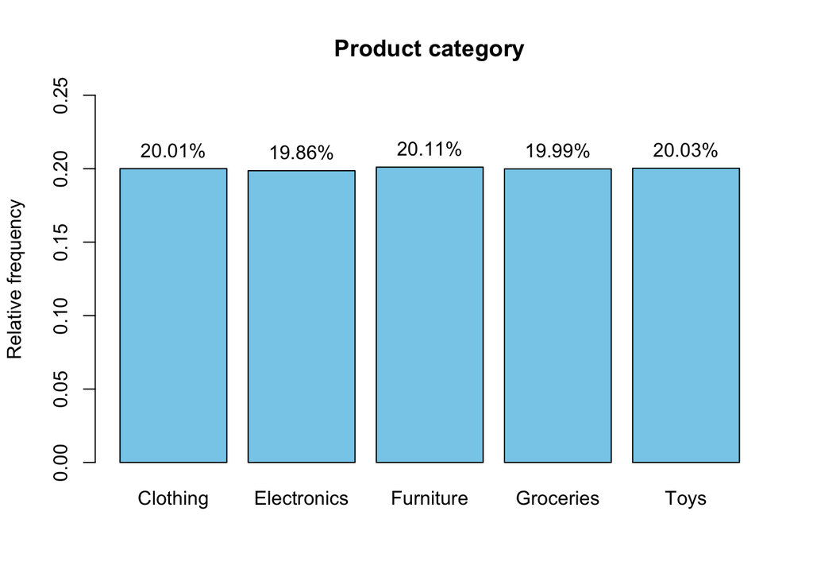

```r
bp <- barplot(prop.table(category_freq), col = "skyblue", ylim = c(0, 0.25),
              main = "Product category", ylab = "Relative frequency")
text(bp, prop.table(category_freq), labels = paste0(round(100 * prop.table(category_freq), 2), "%"), pos = 3)
```

Kategooriad on **peaaegu täiesti ühtlaselt** esindatud: igaühe osakaal on ligikaudu 20%. Kõige sagedasem on Furniture (20.11%), kõige harvem Electronics (19.86%). Vahe on alla 0,3 protsendipunkti, seega selgelt tüüpilist ega harva esinevat kategooriat ei ole.

### 5.2.2 Sihttunnuse `Units.Sold` kirjeldav analüüs

Abifunktsioon arvkarakteristikute leidmiseks:

```r
describe_numeric <- function(x) {
  skewness <- mean((x - mean(x))^3) / sd(x)^3
  round(c(n = length(x), mean = mean(x), sd = sd(x), min = min(x),
          Q1 = unname(quantile(x, 0.25)), median = median(x), Q3 = unname(quantile(x, 0.75)),
          max = max(x), IQR = IQR(x), skewness = skewness,
          n_outliers = length(boxplot.stats(x)$out)), 2)
}
```

Funktsioon suhteliste sageduste histogrammi joonistamiseks:

```r
plot_relative_hist <- function(x, breaks, main, xlab) {
  h <- hist(x, breaks = breaks, plot = FALSE)
  h$counts <- h$counts / sum(h$counts)
  plot(h, col = "skyblue", main = main, xlab = xlab, ylab = "Relative frequency",
       ylim = c(0, 1.1 * max(h$counts)), yaxt = "n")
  axis(2, at = pretty(c(0, max(h$counts))), las = 1)
  invisible(h)
}
```

Arvkarakteristikud:

```r
describe_numeric(retail$Units.Sold)
```

```
##          n       mean         sd        min         Q1     median         Q3
##   73100.00     136.46     108.92       0.00      49.00     107.00     203.00
##        max        IQR   skewness n_outliers
##     499.00     154.00       0.91     715.00
```

Histogramm ja karpdiagramm:

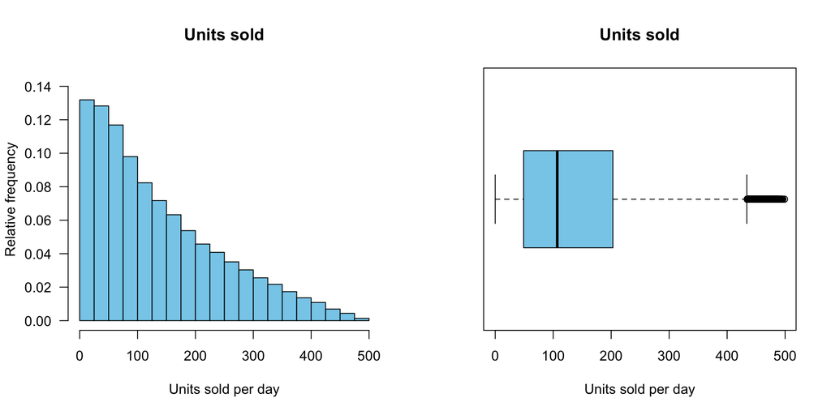

```r
par(mfrow = c(1, 2))
plot_relative_hist(retail$Units.Sold, breaks = seq(0, 500, by = 25),
                   main = "Units sold", xlab = "Units sold per day")
boxplot(retail$Units.Sold, col = "skyblue", horizontal = TRUE, main = "Units sold", xlab = "Units sold per day")
```

Sagedustabel:

```r
sold_classes <- cut(retail$Units.Sold, breaks = seq(0, 500, by = 50), include.lowest = TRUE, right = FALSE)
sold_freq <- table(sold_classes)
data.frame(count = as.vector(sold_freq), relative = round(as.vector(prop.table(sold_freq)), 4),
           row.names = names(sold_freq))
```

```
##           count relative
## [0,50)    18642   0.2550
## [50,100)  15825   0.2165
## [100,150) 11298   0.1546
## [150,200)  8631   0.1181
## [200,250)  6364   0.0871
## [250,300)  4808   0.0658
## [300,350)  3489   0.0477
## [350,400)  2296   0.0314
## [400,450)  1310   0.0179
## [450,500]   437   0.0060
```

Suurima müügiga objektid:

```r
head(retail[order(-retail$Units.Sold), c("Units.Sold", "Inventory.Level", "Category", "Store.ID", "Month")], 10)
```

```
##       Units.Sold Inventory.Level    Category Store.ID Month
## 53158        499             499   Furniture     S003    06
## 19112        496             500        Toys     S001    07
## 73061        496             497 Electronics     S004    01
## 39257        495             498        Toys     S003    01
## 40288        494             495   Groceries     S005    02
## 71293        494             498   Groceries     S005    12
## 36572        493             497   Groceries     S004    01
## 19936        492             495 Electronics     S002    07
## 8767         491             495   Groceries     S004    03
## 11017        491             497 Electronics     S001    04
```

- **Sümmeetria.** Müügi jaotus on **paremale kaldu** (asümmeetriakordaja 0.91). Väikseid päevamüüke on palju, suuri vähem. Histogrammi järgi on sagedus suurim väikseimate väärtuste juures ja kahaneb müügikoguse kasvades ühtlaselt, peaaegu lineaarselt. Põhjus on selles, et müük on piiratud laoseisuga. Suur müük on võimalik ainult siis, kui laoseis on suur.
- **Keskmine ja mediaan.** Keskmine müük on 136.46 tk, mediaan 107 tk. Keskmine on mediaanist suurem, mis kinnitab paremale kaldu jaotust.
- **Tüüpilised väärtused.** Pooled päevamüügid jäävad vahemikku 49–203 tk (Q1–Q3). Kõige sagedasem müügiklass on [0,50) tk (25.5% päevadest).
- **Min ja max.** Min 0 tk (müügita päevi on 360), max 499 tk.
- **Erindid.** Karpdiagrammi reegli (1,5 × IQR) järgi on erindeid **715** (0.98%). Need on päevad, mil müüdi üle 434 tk.
- **Probleemsed objektid.** Suurima müügiga päevadel oli alati ka suur laoseis (lähedane maksimumile 500) ja peaaegu kogu laoseis müüdi ära. Need objektid on loogilised ega ole vead. Probleemsed ei ole ka müügita päevad, mida võib päris kaupluses samuti ette tulla.

### 5.2.3 Arvulise tunnuse `Inventory.Level` kirjeldav analüüs

Arvkarakteristikud:

```r
describe_numeric(retail$Inventory.Level)
```

```
##          n       mean         sd        min         Q1     median         Q3
##   73100.00     274.47     129.95      50.00     162.00     273.00     387.00
##        max        IQR   skewness n_outliers
##     500.00     225.00       0.01       0.00
```

Histogramm ja karpdiagramm:

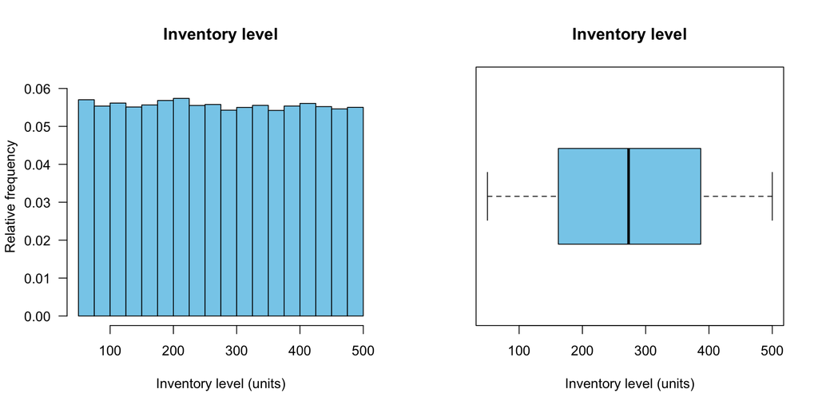

```r
par(mfrow = c(1, 2))
plot_relative_hist(retail$Inventory.Level, breaks = seq(50, 500, by = 25),
                   main = "Inventory level", xlab = "Inventory level (units)")
boxplot(retail$Inventory.Level, col = "skyblue", horizontal = TRUE, main = "Inventory level", xlab = "Inventory level (units)")
```

Sagedustabel:

```r
inventory_classes <- cut(retail$Inventory.Level, breaks = seq(50, 500, by = 50), include.lowest = TRUE)
inventory_freq <- table(inventory_classes)
data.frame(count = as.vector(inventory_freq), relative = round(as.vector(prop.table(inventory_freq)), 4),
           row.names = names(inventory_freq))
```

```
##           count relative
## [50,100]   8214   0.1124
## (100,150]  8132   0.1112
## (150,200]  8222   0.1125
## (200,250]  8252   0.1129
## (250,300]  8044   0.1100
## (300,350]  8080   0.1105
## (350,400]  8009   0.1096
## (400,450]  8133   0.1113
## (450,500]  8014   0.1096
```

- **Sümmeetria.** Laoseisu jaotus on **sümmeetriline** (asümmeetriakordaja 0.01, praktiliselt 0) ja **ühtlane**. Histogrammi kõik tulbad on peaaegu sama kõrgusega, iga 50-ühikuline vahemik sisaldab ~11% objektidest.
- **Keskmine ja mediaan.** Keskmine 274.47 ja mediaan 273 on peaaegu võrdsed, nagu sümmeetrilise jaotuse puhul peab.
- **Tüüpilised väärtused.** Ühtlase jaotuse puhul ei ole ühtki tüüpilist väärtust. Kõik laoseisud vahemikus 50–500 on võrdselt tõenäolised. Pooled väärtused jäävad vahemikku 162–387.
- **Min ja max.** Min 50, max 500. Need on täpselt ümmargused piirid, mis viitab sellele, et väärtused on genereeritud ühtlasest jaotusest vahemikus 50–500.
- **Erindid.** Erindeid on 0, sest ühtlasel jaotusel ei ole pikki sabasid.
- **Probleemsed objektid.** Erindite mõttes probleemseid objekte ei ole. Ebarealistlik on aga jaotuse kuju ise: päris kaupluses sõltuks laoseis tootest (nt mööblit hoitakse laos vähem kui toidukaupu).

### 5.2.4 Sihttunnuse sõltuvus tootekategooriast

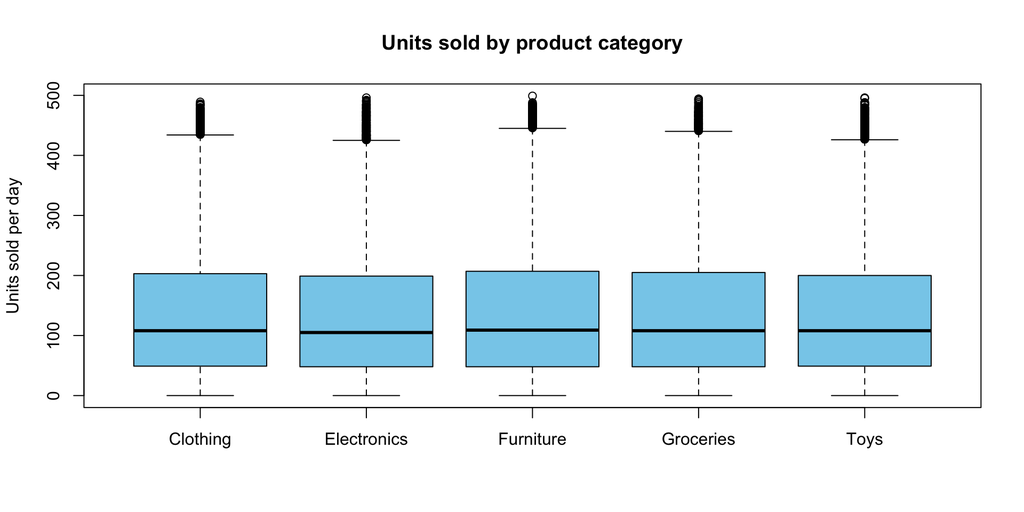

```r
boxplot(Units.Sold ~ Category, data = retail, col = "skyblue",
        main = "Units sold by product category", xlab = "", ylab = "Units sold per day")
```

Müügi arvkarakteristikud kategooriate kaupa:

```r
round(t(sapply(split(retail$Units.Sold, retail$Category),
               function(x) c(n = length(x), mean = mean(x), median = median(x), sd = sd(x),
                             Q1 = unname(quantile(x, 0.25)), Q3 = unname(quantile(x, 0.75))))), 1)
```

```
##                 n  mean median    sd Q1  Q3
## Clothing    14626 136.7    108 108.4 49 203
## Electronics 14521 135.0    105 108.4 48 199
## Furniture   14699 137.8    109 110.0 48 207
## Groceries   14611 136.9    108 109.3 48 205
## Toys        14643 135.9    108 108.4 49 200
```

# 6 Kokkuvõte

Töös analüüsiti 73100 objektist koosnevat jaekaupluste müügiandmestikku (5 kauplust, 20 toodet, 731 päeva). Andmestik oli tehniliselt puhas: duplikaate, `NA` väärtusi ega tühje lahtreid ei olnud. Sisuline kontroll näitas aga mitut probleemi:

- `Seasonality` ei vasta kuupäevale. See asendati kuupäevast tuletatud aastaajaga `Season`.
- Kauplused ei ole seotud kindla piirkonnaga ja tooted ei ole seotud kindla kategooriaga.
- `Demand.Forecast` sisaldas 673 võimatut negatiivset väärtust ja on arvutatud tegeliku müügi põhjal. Tunnus jäeti välja.

Puhastatud andmestikus on 14 tunnust: 6 arvulist ja 8 faktorit.

Sihttunnus `Units.Sold` on paremale kaldu jaotusega (mediaan 107 tk, keskmine 136.5 tk). Ainus müüki selgitav tegur on **laoseis**: seos on positiivne (r ≈ 0,59) ja laoseis on müügi ülempiir. Hinnal, allahindlusel, tootekategoorial, kauplusel, piirkonnal, ilmal, kampaaniatel ja aastaajal müügiga seost ei ole.

Andmestik on **sünteetiline** ja tunnused on genereeritud suures osas üksteisest sõltumatult. Seetõttu ei saa tulemuste põhjal teha järeldusi päris jaekaubanduse kohta. Tulevases projektis tuleks seda arvestada: müügi modelleerimisel on mõtet kasutada peamiselt laoseisu ja mudel ei saa selgitada suuremat osa müügi hajuvusest.

# 7 Kasutatud materjalid

- A. Chauhan. *Retail Store Inventory Forecasting Dataset.* Kaggle: https://www.kaggle.com/datasets/anirudhchauhan/retail-store-inventory-forecasting-dataset
- O. Dunajeva. Seminaritöö 1 lahendamise näidis (NHANES andmestik), RAM0580 Andmeanalüüs.